# Método delta y generación de escenarios futuros

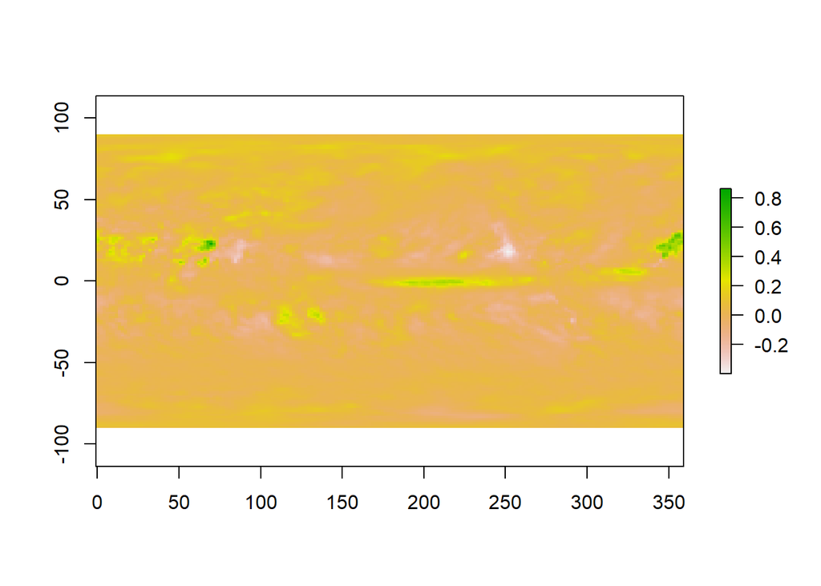

```r
# precipitación
pr.f <- brick("pr_mon_ens_ssp585_192_ave.nc")
pr.f <- pr.f*(30*24*60*60)
pr.hist <- pr.f[[1441:1812]]
t2 <- split(seq_len(372), rep(1:12, length.out=372))
pr.hist.avg <- lapply(1:12, function(x) pr.hist[[t2[[x]]]])
pr.hist.avg <- lapply(1:12, function(x) mean(pr.hist.avg[[x]]))
pr.hist.avg <- stack(pr.hist.avg)
meses <- seq(as.Date("2000-01-01"), as.Date("2000-12-01"), by = "months")
names(pr.hist.avg) <- meses
p1 <- pr.f[[1813:3012]]
delta_pr_ens_ssp585_192 <- (p1 - pr.hist.avg)/pr.hist.avg
dates <- seq(as.Date("2001-01-01"), as.Date("2100-12-01"), by = "months")
names(delta_pr_ens_ssp585_192) <- dates
plot(delta_pr_ens_ssp585_192[[100]])
```

Rotar los rasters

```r
delta_tasmax_ens_ssp585_192 <- terra::rotate(delta_tasmax_ens_ssp585_192, left=TRUE)
delta_tasmin_ens_ssp585_192 <- terra::rotate(delta_tasmin_ens_ssp585_192, left=TRUE)
delta_pr_ens_ssp585_192 <- terra::rotate(delta_pr_ens_ssp585_192, left=TRUE)
```

Cálculo de Delta para temperatura promedio anual

```r
p <- lapply(1:1200, function(x) mean(delta_tasmax_ens_ssp585_192[[x]], delta_tasmin_ens_ssp585_192[[x]]))
tasmean_ssp585 <- stack(p)
dates <- seq(as.Date("2001-01-01"), as.Date("2100-12-01"), by = "months")
names(tasmean_ssp585) <- dates
t1 <- split(seq_len(1200), rep(1:100, each=12))
t2 <- lapply(1:100, function(x) tasmean_ssp585[[t1[[x]]]])
delta_bio1_ssp585 <- lapply(1:100, function(x) mean(t2[[x]]))
delta_bio1_ssp585 <- stack(delta_bio1_ssp585)
```

```r
delta_bio1_ssp585
```

```
## class      : RasterStack
## dimensions : 144, 192, 27648, 100  (nrow, ncol, ncell, nlayers)
## resolution : 1.875, 1.25  (x, y)
## extent     : -179.0625, 180.9375, -90, 90  (xmin, xmax, ymin, ymax)
## crs        : +proj=longlat +datum=WGS84 +no_defs
## names      :      layer.1,      layer.2,      layer.3,      layer.4,      layer.5,      layer.6,      layer.7,      layer.8,      layer.9,     layer.10,     layer.11,     layer.12,     layer.13,     layer.14,     layer.15, ...
## min values :  0.028977258,  0.043724390,  0.027354700,  0.035543544, -0.003240774, -0.044730862,  0.036270548,  0.071346314,  0.038030026,  0.057134025,  0.120097659,  0.148231511,  0.122626428,  0.123610917,  0.157369010, ...
## max values :     2.262512,     2.544159,     2.898864,     3.334587,     3.480233,     3.877360,     4.174153,     4.499359,     4.450591,     4.582206,     4.808756,     4.922228,     5.119691,     5.327759,     5.151492, ...
```

Cálculo de Delta para precipitación anual

```r
t1 <- split(seq_len(1200), rep(1:100, each=12))
t2 <- lapply(1:100, function(x) delta_pr_ens_ssp585_192[[t1[[x]]]])
delta_bio12_ssp585 <- lapply(1:100, function(x) mean(t2[[x]]))
delta_bio12_ssp585 <- stack(delta_bio12_ssp585)
```

Exploramos los deltas para bio1 y bio12

```r
delta_bio1_ssp585
```

```
## class      : RasterStack
## dimensions : 144, 192, 27648, 100  (nrow, ncol, ncell, nlayers)
## resolution : 1.875, 1.25  (x, y)
## extent     : -179.0625, 180.9375, -90, 90  (xmin, xmax, ymin, ymax)
## crs        : +proj=longlat +datum=WGS84 +no_defs
## names      :      layer.1,      layer.2,      layer.3,      layer.4,      layer.5,      layer.6,      layer.7,      layer.8,      layer.9,     layer.10,     layer.11,     layer.12,     layer.13,     layer.14,     layer.15, ...
## min values :  0.028977258,  0.043724390,  0.027354700,  0.035543544, -0.003240774, -0.044730862,  0.036270548,  0.071346314,  0.038030026,  0.057134025,  0.120097659,  0.148231511,  0.122626428,  0.123610917,  0.157369010, ...
## max values :     2.262512,     2.544159,     2.898864,     3.334587,     3.480233,     3.877360,     4.174153,     4.499359,     4.450591,     4.582206,     4.808756,     4.922228,     5.119691,     5.327759,     5.151492, ...
```

```r
delta_bio12_ssp585
```

```
## class      : RasterStack
## dimensions : 144, 192, 27648, 100  (nrow, ncol, ncell, nlayers)
## resolution : 1.875, 1.25  (x, y)
## extent     : -179.0625, 180.9375, -90, 90  (xmin, xmax, ymin, ymax)
## crs        : +proj=longlat +datum=WGS84 +no_defs
## names      :    layer.1,    layer.2,    layer.3,    layer.4,    layer.5,    layer.6,    layer.7,    layer.8,    layer.9,   layer.10,   layer.11,   layer.12,   layer.13,   layer.14,   layer.15, ...
## min values : -0.1287373, -0.1750321, -0.1327746, -0.1325774, -0.1300850, -0.1017301, -0.1469527, -0.1140420, -0.1097782, -0.1241216, -0.1367964, -0.1681148, -0.1452880, -0.1302457, -0.1374241, ...
## max values :  0.4218842,  0.4902218,  0.3677308,  0.4336316,  0.3922701,  0.4383883,  0.5456928,  0.6159500,  0.3678838,  0.4691615,  0.4231700,  0.4288572,  0.3792099,  0.4142094,  0.5729208, ...
```

Ahora necesitamos ajustar los datos a la resolución espacial de la climatología actual. En este caso tenemos un raster de ~1°x1° de temperatura promedio anual (bio1) generado a partir de datos del WorldClim.

```r
delta_bio1_ssp585.r <- projectRaster(from=delta_bio1_ssp585, to=r, crs=crs(r), method="bilinear")
delta_bio1_ssp585.r
```

```
## class      : RasterBrick
## dimensions : 180, 360, 64800, 100  (nrow, ncol, ncell, nlayers)
## resolution : 1, 1  (x, y)
## extent     : -180, 180, -90, 90  (xmin, xmax, ymin, ymax)
## crs        : +proj=longlat +datum=WGS84 +no_defs
## source     : r_tmp_2023-10-30_183147.682356_25412_16904.grd
## names      :       layer.1,       layer.2,       layer.3,       layer.4,       layer.5,       layer.6,       layer.7,       layer.8,       layer.9,      layer.10,      layer.11,      layer.12,      layer.13,      layer.14,      layer.15, ...
## min values :  0.0313846005,  0.0461961208,  0.0279455474,  0.0361689325,  0.0001373057, -0.0425215474,  0.0377466023,  0.0756863605,  0.0399598896,  0.0618616620,  0.1247502250,  0.1487914975,  0.1241111506,  0.1251624320,  0.1626065266, ...
## max values :      2.216503,      2.507488,      2.873116,      3.327629,      3.446888,      3.816464,      4.112271,      4.479281,      4.439846,      4.559672,      4.774508,      4.894906,      5.078867,      5.272557,      5.108799, ...
```

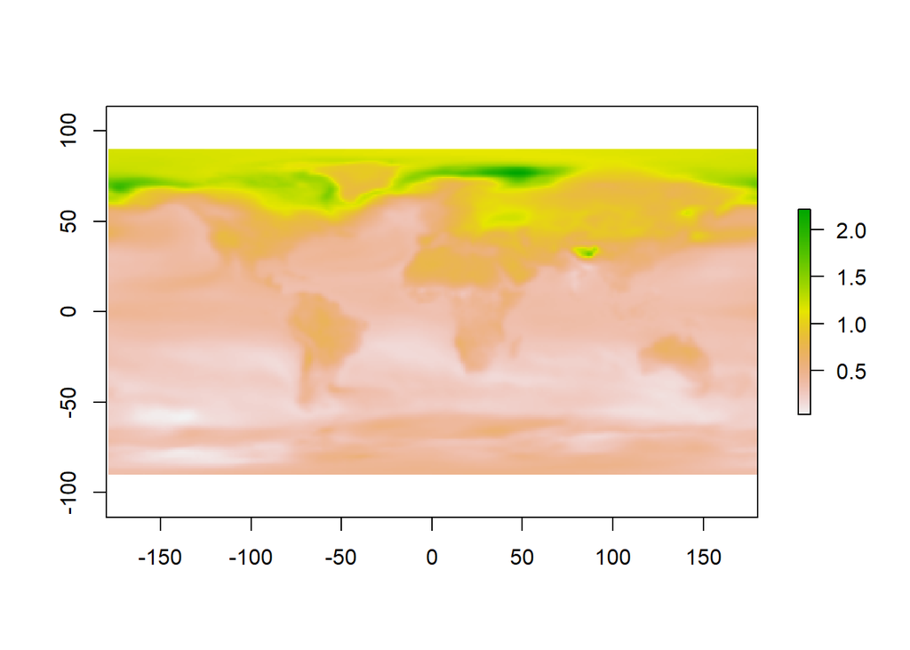

```r
plot(delta_bio1_ssp585.r[[1]])
```

```r
delta_bio12_ssp585.r <- projectRaster(from=delta_bio12_ssp585, to=r, crs=crs(r), method="bilinear")
delta_bio12_ssp585.r
```

```
## class      : RasterBrick
## dimensions : 180, 360, 64800, 100  (nrow, ncol, ncell, nlayers)
## resolution : 1, 1  (x, y)
## extent     : -180, 180, -90, 90  (xmin, xmax, ymin, ymax)
## crs        : +proj=longlat +datum=WGS84 +no_defs
## source     : r_tmp_2023-10-30_183150.091265_25412_69981.grd
## names      :    layer.1,    layer.2,    layer.3,    layer.4,    layer.5,    layer.6,    layer.7,    layer.8,    layer.9,   layer.10,   layer.11,   layer.12,   layer.13,   layer.14,   layer.15, ...
## min values : -0.1263510, -0.1641282, -0.1273414, -0.1309281, -0.1245210, -0.1000774, -0.1418430, -0.1077873, -0.1058037, -0.1227938, -0.1276665, -0.1671196, -0.1440533, -0.1275869, -0.1353514, ...
## max values :  0.4016378,  0.4633300,  0.3635910,  0.4238174,  0.3786027,  0.3883792,  0.5009215,  0.5216511,  0.3428648,  0.4615619,  0.3747924,  0.3827242,  0.3782315,  0.3882016,  0.5370588, ...
```

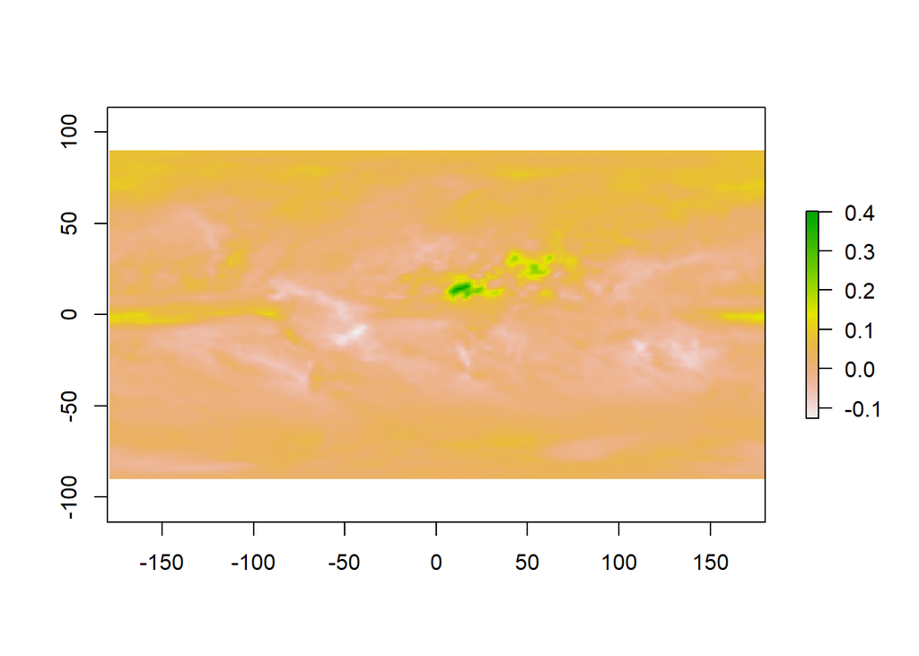

```r
plot(delta_bio12_ssp585.r[[1]])
```

Ahora vamos a agregar los deltas a la climatología de WorldClim para crear escenarios futuros de temperatura promedio anual (bio1) y precipitación anual (bio12).

Primero cargamos las dos variables de worldclim

```r
bio1 <- raster("bio_01.tif")
bio12 <- raster("bio_12.tif")
```

Luego adicionamos los deltas a la climatología.

```r
bio1_ssp585 <- bio1+delta_bio1_ssp585.r
bio12_ssp585 <- (1+delta_bio12_ssp585.r)*bio12
```

Vamos a graficar para el año 2100

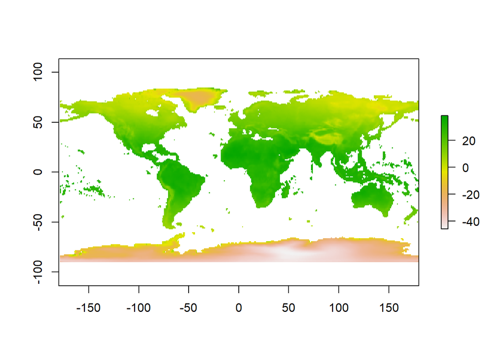

```r
plot(bio1_ssp585[[100]])
```

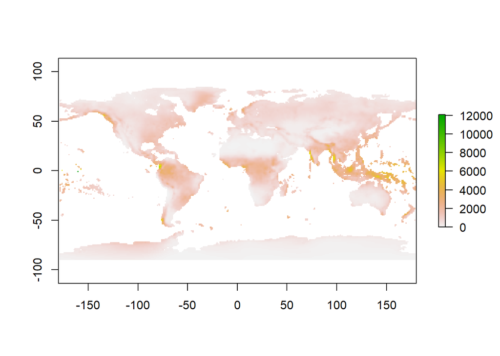

```r
plot(bio12_ssp585[[100]])
```

Tarea: ¿Cómo generarían los escenarios futuros pero para los datos mensuales de temperatura y precipitación?

Pista: Con lo aprendido en las sesiones anteriores fácilmente lo podrían implementar.

Elaborado por Julián A. Velasco Material para el curso “Herramientas para el análisis de impactos de cambio climático en sistemas naturales y humanos”.